# Radio Tag-Only CJS Models

Kevin See<sup>1,✉</sup>, Mike Ackerman<sup>1</sup>, and Nick Porter<sup>1</sup>

August 17, 2020

<sup>1</sup> Biomark, Inc. 705 South 8th St., Boise, Idaho, 83702, USA

<sup>✉</sup> Correspondence: Kevin See <kevin.see@merck.com>

# 1 Introduction

We are interested primarily in estimating survival of fish from release (e.g. at the Lower Lemhi screw trap) between each RT site using radio tag detections only, with a Cormack Jolly-Seber (CJS) model.

# 2 Methods

## 2.1 Data

The data is radio tag (RT) detections, which were downloaded from various fixed sites over the last three years. We compressed these detections and summarized capture histories, eliminating any detections that indicated upstream movement.

In 2017-18 and 2018-19, we focused on tags that were released from the lower Lemhi rotary screw trap (code LLRTP). In 2019-20, we also included tags released from the upper Lemhi rotary screw trap (code LEMTRP). To do this, we allowed tags released at the lower trap (LLRTP) to enter the CJS model upon their first radio detection, similar to how we treated batch 2 and batch 3 tags. This did result in 15 tags that were released at the lower trap but were never subsequently detected anywhere being dropped completely from the model.

## 2.2 Model

# 3 Results

We can extract summary statistics from the posteriors, and construct plots of detection probabilities, survival probabilities and cumulative survival probabilities.

Table 3.1: Estimates of survival between detection points.

| season | Reach | mean | se | cv | lwrCI | uprCI |
| --- | --- | --- | --- | --- | --- | --- |
| 17_18 | LLRTP to LH | 0.595 | 0.060 | 0.101 | 0.478 | 0.716 |
| 17_18 | LH to MB | 0.836 | 0.069 | 0.083 | 0.687 | 0.955 |
| 17_18 | MB to TR | 0.910 | 0.054 | 0.060 | 0.788 | 0.990 |
| 17_18 | TR to RR | 0.843 | 0.062 | 0.074 | 0.712 | 0.948 |
| 17_18 | RR to BG | 0.941 | 0.044 | 0.047 | 0.830 | 0.996 |
| 17_18 | BG to NF | 0.927 | 0.047 | 0.051 | 0.813 | 0.994 |
| 17_18 | NF to DW | 0.827 | 0.071 | 0.086 | 0.674 | 0.947 |
| 17_18 | DW to LR | 0.878 | 0.071 | 0.081 | 0.716 | 0.984 |
| 17_18 | LR to SR | 0.703 | 0.114 | 0.162 | 0.481 | 0.928 |
| 17_18 | SR to CC | 0.795 | 0.141 | 0.178 | 0.480 | 0.990 |
| 18_19 | LLRTP to LH | 0.838 | 0.043 | 0.052 | 0.749 | 0.922 |
| 18_19 | LH to CA | 0.835 | 0.047 | 0.057 | 0.736 | 0.922 |
| 18_19 | CA to TR | 0.936 | 0.033 | 0.035 | 0.863 | 0.987 |
| 18_19 | TR to RR | 0.923 | 0.031 | 0.034 | 0.852 | 0.977 |
| 18_19 | RR to NF | 0.929 | 0.036 | 0.038 | 0.851 | 0.989 |
| 18_19 | NF to DW | 0.822 | 0.048 | 0.058 | 0.722 | 0.908 |
| 18_19 | DW to LR | 0.820 | 0.063 | 0.077 | 0.692 | 0.940 |
| 18_19 | LR to SR | 0.613 | 0.069 | 0.113 | 0.476 | 0.745 |
| 18_19 | SR to CC | 0.712 | 0.085 | 0.119 | 0.540 | 0.882 |
| 18_19 | CC to YP | 0.596 | 0.132 | 0.221 | 0.373 | 0.903 |
| 18_19 | YP to VC | 0.282 | 0.099 | 0.353 | 0.123 | 0.504 |
| 18_19 | VC to SB | 0.844 | 0.131 | 0.156 | 0.522 | 0.996 |
| 19_20 | LEMTRP to BC | 0.941 | 0.050 | 0.053 | 0.812 | 0.998 |
| 19_20 | BC to TC | 0.679 | 0.083 | 0.122 | 0.535 | 0.859 |
| 19_20 | TC to EC | 0.808 | 0.085 | 0.105 | 0.631 | 0.957 |
| 19_20 | EC to SS | 0.911 | 0.063 | 0.069 | 0.771 | 0.996 |
| 19_20 | SS to EU | 0.685 | 0.143 | 0.209 | 0.432 | 0.968 |
| 19_20 | EU to LF | 0.361 | 0.114 | 0.317 | 0.176 | 0.617 |
| 19_20 | LF to DD | 0.676 | 0.154 | 0.227 | 0.369 | 0.953 |
| 19_20 | DD to LH | 0.740 | 0.092 | 0.124 | 0.550 | 0.904 |
| 19_20 | LH to MB | 0.818 | 0.059 | 0.072 | 0.686 | 0.920 |
| 19_20 | MB to TR | 0.875 | 0.050 | 0.057 | 0.766 | 0.963 |
| 19_20 | TR to NF | 0.818 | 0.057 | 0.069 | 0.688 | 0.916 |
| 19_20 | NF to DW | 0.962 | 0.032 | 0.034 | 0.877 | 0.999 |
| 19_20 | DW to LR | 0.871 | 0.070 | 0.080 | 0.724 | 0.990 |
| 19_20 | LR to SR | 0.584 | 0.090 | 0.154 | 0.415 | 0.764 |
| 19_20 | SR to CC | 0.912 | 0.071 | 0.078 | 0.739 | 0.997 |

Table 3.2: Estimates of detection probability.

| season | site | mean | se | cv | lwrCI | uprCI |
| --- | --- | --- | --- | --- | --- | --- |
| 17_18 | LH | 0.660 | 0.071 | 0.107 | 0.516 | 0.789 |
| 17_18 | MB | 0.709 | 0.070 | 0.098 | 0.567 | 0.832 |
| 17_18 | TR | 0.810 | 0.063 | 0.078 | 0.677 | 0.920 |
| 17_18 | RR | 0.802 | 0.066 | 0.083 | 0.660 | 0.911 |
| 17_18 | BG | 0.910 | 0.048 | 0.053 | 0.794 | 0.980 |
| 17_18 | NF | 0.896 | 0.055 | 0.061 | 0.767 | 0.979 |
| 17_18 | DW | 0.878 | 0.064 | 0.073 | 0.717 | 0.973 |
| 17_18 | LR | 0.894 | 0.067 | 0.075 | 0.736 | 0.985 |
| 17_18 | SR | 0.810 | 0.111 | 0.137 | 0.555 | 0.970 |
| 17_18 | CC | 0.487 | 0.139 | 0.285 | 0.239 | 0.769 |
| 18_19 | LH | 0.634 | 0.051 | 0.080 | 0.531 | 0.732 |
| 18_19 | CA | 0.663 | 0.050 | 0.075 | 0.561 | 0.758 |
| 18_19 | TR | 0.858 | 0.038 | 0.044 | 0.776 | 0.923 |
| 18_19 | RR | 0.848 | 0.039 | 0.046 | 0.766 | 0.916 |
| 18_19 | NF | 0.848 | 0.041 | 0.048 | 0.763 | 0.918 |
| 18_19 | DW | 0.879 | 0.043 | 0.049 | 0.781 | 0.948 |
| 18_19 | LR | 0.814 | 0.061 | 0.075 | 0.679 | 0.920 |
| 18_19 | SR | 0.833 | 0.067 | 0.081 | 0.686 | 0.941 |
| 18_19 | CC | 0.885 | 0.073 | 0.083 | 0.710 | 0.986 |
| 18_19 | YP | 0.746 | 0.138 | 0.185 | 0.456 | 0.963 |
| 18_19 | VC | 0.713 | 0.158 | 0.221 | 0.382 | 0.954 |
| 18_19 | SB | 0.859 | 0.121 | 0.141 | 0.554 | 0.995 |
| 19_20 | BC | 0.188 | 0.041 | 0.218 | 0.115 | 0.273 |
| 19_20 | TC | 0.413 | 0.069 | 0.168 | 0.281 | 0.546 |
| 19_20 | EC | 0.665 | 0.070 | 0.106 | 0.521 | 0.794 |
| 19_20 | SS | 0.724 | 0.072 | 0.100 | 0.568 | 0.858 |
| 19_20 | EU | 0.534 | 0.124 | 0.232 | 0.319 | 0.784 |
| 19_20 | LF | 0.680 | 0.143 | 0.211 | 0.362 | 0.911 |
| 19_20 | DD | 0.645 | 0.153 | 0.237 | 0.336 | 0.907 |
| 19_20 | LH | 0.829 | 0.086 | 0.104 | 0.633 | 0.961 |
| 19_20 | MB | 0.891 | 0.051 | 0.057 | 0.778 | 0.968 |
| 19_20 | TR | 0.901 | 0.046 | 0.051 | 0.796 | 0.971 |
| 19_20 | NF | 0.875 | 0.052 | 0.060 | 0.758 | 0.958 |
| 19_20 | DW | 0.903 | 0.046 | 0.050 | 0.799 | 0.973 |
| 19_20 | LR | 0.798 | 0.074 | 0.093 | 0.644 | 0.922 |
| 19_20 | SR | 0.798 | 0.086 | 0.108 | 0.612 | 0.937 |
| 19_20 | CC | 0.843 | 0.083 | 0.099 | 0.655 | 0.972 |

Table 3.3: Estimates of cumulative transition up to detection points.

| season | site | mean | se | cv | lwrCI | uprCI |
| --- | --- | --- | --- | --- | --- | --- |
| 17_18 | LLRTP | 1.000 | 0.000 | 0.000 | 1.000 | 1.000 |
| 17_18 | LH | 0.595 | 0.060 | 0.101 | 0.478 | 0.716 |
| 17_18 | MB | 0.496 | 0.055 | 0.111 | 0.389 | 0.609 |
| 17_18 | TR | 0.451 | 0.052 | 0.116 | 0.347 | 0.556 |
| 17_18 | RR | 0.380 | 0.050 | 0.132 | 0.287 | 0.479 |
| 17_18 | BG | 0.357 | 0.049 | 0.137 | 0.267 | 0.454 |
| 17_18 | NF | 0.331 | 0.048 | 0.145 | 0.240 | 0.430 |
| 17_18 | DW | 0.274 | 0.046 | 0.167 | 0.188 | 0.368 |
| 17_18 | LR | 0.240 | 0.044 | 0.181 | 0.158 | 0.327 |
| 17_18 | SR | 0.169 | 0.041 | 0.241 | 0.097 | 0.255 |
| 17_18 | CC | 0.134 | 0.039 | 0.293 | 0.065 | 0.214 |
| 18_19 | LLRTP | 1.000 | 0.000 | 0.000 | 1.000 | 1.000 |
| 18_19 | LH | 0.838 | 0.043 | 0.052 | 0.749 | 0.922 |
| 18_19 | CA | 0.699 | 0.042 | 0.060 | 0.616 | 0.781 |
| 18_19 | TR | 0.654 | 0.042 | 0.064 | 0.572 | 0.731 |
| 18_19 | RR | 0.604 | 0.042 | 0.070 | 0.523 | 0.687 |
| 18_19 | NF | 0.561 | 0.044 | 0.078 | 0.472 | 0.646 |
| 18_19 | DW | 0.460 | 0.042 | 0.091 | 0.380 | 0.541 |
| 18_19 | LR | 0.377 | 0.043 | 0.113 | 0.295 | 0.464 |
| 18_19 | SR | 0.231 | 0.034 | 0.146 | 0.170 | 0.298 |
| 18_19 | CC | 0.164 | 0.029 | 0.179 | 0.113 | 0.226 |
| 18_19 | YP | 0.097 | 0.026 | 0.271 | 0.054 | 0.160 |
| 18_19 | VC | 0.027 | 0.010 | 0.382 | 0.011 | 0.050 |
| 18_19 | SB | 0.022 | 0.009 | 0.394 | 0.009 | 0.043 |
| 19_20 | LEMTRP | 1.000 | 0.000 | 0.000 | 1.000 | 1.000 |
| 19_20 | BC | 0.941 | 0.050 | 0.053 | 0.812 | 0.998 |
| 19_20 | TC | 0.638 | 0.074 | 0.116 | 0.508 | 0.795 |
| 19_20 | EC | 0.512 | 0.056 | 0.109 | 0.411 | 0.625 |
| 19_20 | SS | 0.466 | 0.056 | 0.121 | 0.362 | 0.579 |
| 19_20 | EU | 0.319 | 0.075 | 0.234 | 0.188 | 0.476 |
| 19_20 | LF | 0.111 | 0.034 | 0.306 | 0.056 | 0.189 |
| 19_20 | DD | 0.074 | 0.025 | 0.332 | 0.034 | 0.129 |
| 19_20 | LH | 0.054 | 0.018 | 0.341 | 0.024 | 0.096 |
| 19_20 | MB | 0.044 | 0.015 | 0.347 | 0.020 | 0.079 |
| 19_20 | TR | 0.039 | 0.014 | 0.350 | 0.017 | 0.070 |
| 19_20 | NF | 0.032 | 0.011 | 0.350 | 0.014 | 0.057 |
| 19_20 | DW | 0.030 | 0.011 | 0.351 | 0.013 | 0.055 |
| 19_20 | LR | 0.027 | 0.010 | 0.361 | 0.011 | 0.049 |
| 19_20 | SR | 0.015 | 0.006 | 0.383 | 0.006 | 0.029 |
| 19_20 | CC | 0.014 | 0.005 | 0.390 | 0.006 | 0.027 |

We also present these results in Figures 3.1, 3.2, 3.3 and 3.4.

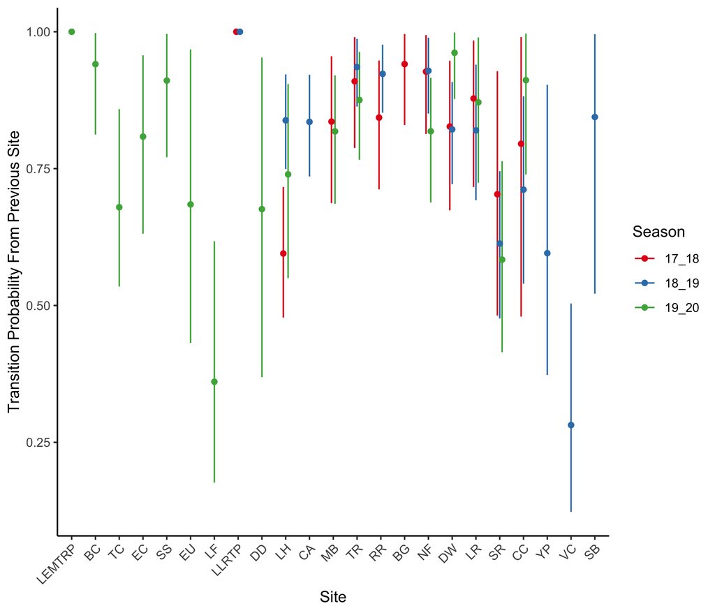

Figure 3.1: Estimates, with 95% confidence intervals, of transition probabilities between detection points

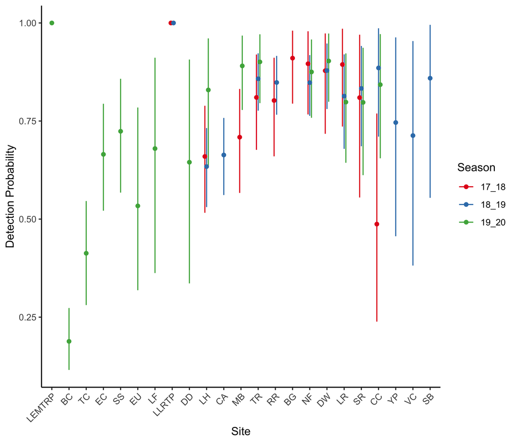

Figure 3.2: Estimates, with 95% confidence intervals, of detection probabilities.

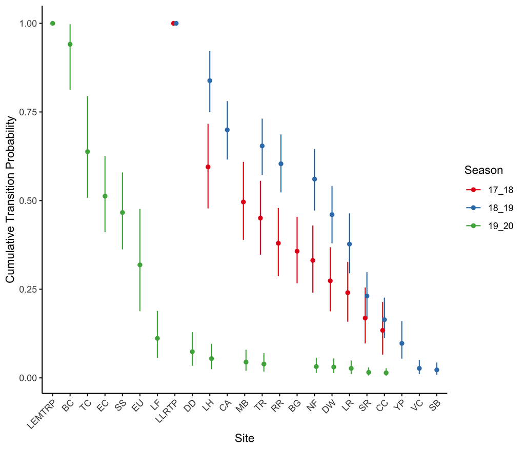

Figure 3.3: Estimates, with 95% confidence intervals, of cumulative transition probability across reaches.

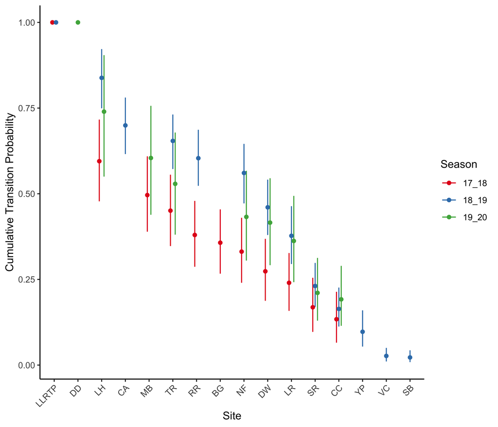

Figure 3.4: Estimates, with 95% confidence intervals, of cumulative transition probability across reaches, resetting the transitions in 2019-20 to start at Lower Lemhi screw trap.

# 4 Discussion

Some of the caveats to keep in mind with CJS models include:

- Estimates of $\phi$ are really estimates of *apparent* survival, or transition probability (i.e. the chance that a fish survives **AND** moves past the next detection point). $1 - \phi_i$ represents the chances that an animal either died in reach $i - 1$, or left the population (became unavailable for detection). The latter is analogous to a fish that hunkers down in a reach to ride out the winter. It may be surviving very well within that reach, or it may have died there, there is no way to tell from only the radio tag observations.